# **Project - AllLife Bank Customer Segmentation**

## **Context**

AllLife Bank wants to focus on its credit card customer base in the next financial year. They have been advised by their marketing research team, that the penetration in the market can be improved. Based on this input, the Marketing team proposes to run personalized campaigns to target new customers as well as upsell to existing customers. Another insight from the market research was that the customers perceive the support services of the back poorly. Based on this, the Operations team wants to upgrade the service delivery model, to ensure that customer queries are resolved faster. Head of Marketing and Head of Delivery both decide to reach out to the Data Science team for help

## **Objective**

To identify different segments in the existing customer, based on their spending patterns as well as past interaction with the bank, using clustering algorithms, and provide recommendations to the bank on how to better market to and service these customers.

## **Data Description**

The data provided is of various customers of a bank and their financial attributes like credit limit, the total number of credit cards the customer has, and different channels through which customers have contacted the bank for any queries (including visiting the bank, online and through a call center).

## **Data Dictionary**

- **Sl_No:** Primary key of the records
- **Customer Key:** Customer identification number
- **Average Credit Limit:** Average credit limit of each customer for all credit cards
- **Total credit cards:** Total number of credit cards possessed by the customer
- **Total visits bank:** Total number of visits that customer made (yearly) personally to the bank
- **Total visits online:** Total number of visits or online logins made by the customer (yearly)
- T**otal calls made:** Total number of calls made by the customer to the bank or its customer service department (yearly)

## **Code Goes Here...**

First I need the various libraries to process, visualize, and sclae the data. Then I need the set of libraries for KMeans clustering followed by those for hierarchical clustering

```python
# Libraries to read, query, and process data
import numpy as np
import pandas as pd

# Libraries to visualize the data
import matplotlib.pyplot as plt
import seaborn as sns

# to scale the data using z-score - needed to ensure that all data dimensions have equal influence
from sklearn.preprocessing import StandardScaler

# to compute distances
from scipy.spatial.distance import cdist

# To suppress the warnings
import warnings
warnings.filterwarnings("ignore")

# To define maximum number of columns to be displayed in a dataframe
pd.set_option("display.max_columns", None)

# To supress scientific notations for a dataframe
pd.set_option("display.float_format", lambda x: "%.3f" % x)
```

```python
# to perform k-means clustering and compute silhouette scores
from sklearn.cluster import KMeans
from sklearn.metrics import silhouette_score

# to visualize the elbow curve and silhouette scores
from yellowbrick.cluster import KElbowVisualizer, SilhouetteVisualizer
```

```python
# to compute distances
from scipy.spatial.distance import pdist

# to perform hierarchical clustering, compute cophenetic correlation, and create dendrograms
from sklearn.cluster import AgglomerativeClustering
from scipy.cluster.hierarchy import dendrogram, linkage, cophenet
```

### **Load Data, make a copy, and do some initial inspection of data**

```python
# Read from Excel file
bankData = pd.read_excel("Credit Card Customer Data.xlsx")
```

```python
# Make a copy of the data for safekeeping
df = bankData.copy()
```

```python
# Let's take a quick look at the number of rows and columns
df.shape
```

```
(660, 7)
```

So we have 660 rows and 7 columns in the dataset, which is not a very large dataset.

```python
# Let's inspect firest few rows
df.head(10)
```

|  | Sl_No | Customer Key | Avg_Credit_Limit | Total_Credit_Cards | Total_visits_bank | Total_visits_online | Total_calls_made |
| --- | --- | --- | --- | --- | --- | --- | --- |
| 0 | 1 | 87073 | 100000 | 2 | 1 | 1 | 0 |
| 1 | 2 | 38414 | 50000 | 3 | 0 | 10 | 9 |
| 2 | 3 | 17341 | 50000 | 7 | 1 | 3 | 4 |
| 3 | 4 | 40496 | 30000 | 5 | 1 | 1 | 4 |
| 4 | 5 | 47437 | 100000 | 6 | 0 | 12 | 3 |
| 5 | 6 | 58634 | 20000 | 3 | 0 | 1 | 8 |
| 6 | 7 | 48370 | 100000 | 5 | 0 | 11 | 2 |
| 7 | 8 | 37376 | 15000 | 3 | 0 | 1 | 1 |
| 8 | 9 | 82490 | 5000 | 2 | 0 | 2 | 2 |
| 9 | 10 | 44770 | 3000 | 4 | 0 | 1 | 7 |

```python
# And the last few rows
df.tail(10)
```

|  | Sl_No | Customer Key | Avg_Credit_Limit | Total_Credit_Cards | Total_visits_bank | Total_visits_online | Total_calls_made |
| --- | --- | --- | --- | --- | --- | --- | --- |
| 650 | 651 | 78996 | 195000 | 10 | 1 | 12 | 2 |
| 651 | 652 | 78404 | 132000 | 9 | 1 | 12 | 2 |
| 652 | 653 | 28525 | 156000 | 8 | 1 | 8 | 0 |
| 653 | 654 | 51826 | 95000 | 10 | 0 | 15 | 1 |
| 654 | 655 | 65750 | 172000 | 10 | 1 | 9 | 1 |
| 655 | 656 | 51108 | 99000 | 10 | 1 | 10 | 0 |
| 656 | 657 | 60732 | 84000 | 10 | 1 | 13 | 2 |
| 657 | 658 | 53834 | 145000 | 8 | 1 | 9 | 1 |
| 658 | 659 | 80655 | 172000 | 10 | 1 | 15 | 0 |
| 659 | 660 | 80150 | 167000 | 9 | 0 | 12 | 2 |

Looks like all of the columns are numeric data. Need to check for null columns and missing data. Also, need to make sure that the SL_No and Customer_Key values are unique for each record and can be skipped from the analysis.

```python
# Let's inspect the data types and null counts
df.info()
```

```
<class 'pandas.core.frame.DataFrame'>
RangeIndex: 660 entries, 0 to 659
Data columns (total 7 columns):
 #   Column               Non-Null Count  Dtype
---  ------               --------------  -----
 0   Sl_No                660 non-null    int64
 1   Customer Key         660 non-null    int64
 2   Avg_Credit_Limit     660 non-null    int64
 3   Total_Credit_Cards   660 non-null    int64
 4   Total_visits_bank    660 non-null    int64
 5   Total_visits_online  660 non-null    int64
 6   Total_calls_made     660 non-null    int64
dtypes: int64(7)
memory usage: 36.2 KB
```

Looks like there are no missing values in the data since all columns have 660 non-null values. Also, we have confirmation that all columns are indeed numeric.

```python
# Let's get a further confirmation
df.isnull().sum()
```

```
Sl_No                  0
Customer Key           0
Avg_Credit_Limit       0
Total_Credit_Cards     0
Total_visits_bank      0
Total_visits_online    0
Total_calls_made       0
dtype: int64
```

Confirmed that there are no nulls in the data

```python
# Let's now describe the data to get an idea of the distribution
df.describe().T
```

|  | count | mean | std | min | 25% | 50% | 75% | max |
| --- | --- | --- | --- | --- | --- | --- | --- | --- |
| Sl_No | 660.000 | 330.500 | 190.670 | 1.000 | 165.750 | 330.500 | 495.250 | 660.000 |
| Customer Key | 660.000 | 55141.444 | 25627.772 | 11265.000 | 33825.250 | 53874.500 | 77202.500 | 99843.000 |
| Avg_Credit_Limit | 660.000 | 34574.242 | 37625.488 | 3000.000 | 10000.000 | 18000.000 | 48000.000 | 200000.000 |
| Total_Credit_Cards | 660.000 | 4.706 | 2.168 | 1.000 | 3.000 | 5.000 | 6.000 | 10.000 |
| Total_visits_bank | 660.000 | 2.403 | 1.632 | 0.000 | 1.000 | 2.000 | 4.000 | 5.000 |
| Total_visits_online | 660.000 | 2.606 | 2.936 | 0.000 | 1.000 | 2.000 | 4.000 | 15.000 |
| Total_calls_made | 660.000 | 3.583 | 2.865 | 0.000 | 1.000 | 3.000 | 5.000 | 10.000 |

#### **Observations**

- Average credit limit ranges from USD 3000 to USD 200,000. Mean is significantly greater than median, so we expect a right skew on the distribution. Since the median is only USD 18,000, we expect outliers.
- Total credit cards ranges from 1 to 10. Median and mean are close together, so we expect a normal distribution.
- Total visits to bank ranges from 0 to 5. Mean and median are close together, so we expect a normal distribution.
- Total online visits ranges from 0 to 15. Mean and median are close to 2, so we expect a right skew with outliers in the data.
- Total calls made ranges from 0 to 10. Median and mean are close together with a slightly higher mean. Expect a slight right skew in the data.

```python
df['Sl_No'].value_counts()
```

```
660    1
226    1
224    1
223    1
222    1
      ..
440    1
439    1
438    1
437    1
1      1
Name: Sl_No, Length: 660, dtype: int64
```

All serial numbers are unique, so this data adds no value to the clustering and can be dropped

```python
df['Customer Key'].value_counts()
```

```
47437    2
37252    2
97935    2
96929    2
50706    2
        ..
66706    1
72339    1
69965    1
85645    1
71681    1
Name: Customer Key, Length: 655, dtype: int64
```

There are actually 5 records of customers with same Id. However, as the FAQ of the problem states that we can ignore this column for clustering, I will drop this column from the data.

## **Data Pre-Processing**

```python
# Drop the two columns that we will not use for clustering
df.drop("Sl_No", axis=1, inplace=True)
df.drop("Customer Key", axis=1, inplace=True)
```

## **Exploratory Data Analysis**

### Note

I am borrowing/copying some utility functions that were used in the MLS sessions instead of trying to create them on my own.

I am borrowing utility functions for univariate analysis as well as for bivariate analysis.

```python
# function to plot a boxplot and a histogram along the same scale.


def histogram_boxplot(data, feature, figsize=(12, 7), kde=False, bins=None):
    """
    Boxplot and histogram combined

    data: dataframe
    feature: dataframe column
    figsize: size of figure (default (12,7))
    kde: whether to the show density curve (default False)
    bins: number of bins for histogram (default None)
    """
    f2, (ax_box2, ax_hist2) = plt.subplots(
        nrows=2,  # Number of rows of the subplot grid= 2
        sharex=True,  # x-axis will be shared among all subplots
        gridspec_kw={"height_ratios": (0.25, 0.75)},
        figsize=figsize,
    )  # creating the 2 subplots
    sns.boxplot(
        data=data, x=feature, ax=ax_box2, showmeans=True, color="violet"
    )  # boxplot will be created and a star will indicate the mean value of the column
    sns.histplot(
        data=data, x=feature, kde=kde, ax=ax_hist2, bins=bins, palette="winter"
    ) if bins else sns.histplot(
        data=data, x=feature, kde=kde, ax=ax_hist2
    )  # For histogram
    ax_hist2.axvline(
        data[feature].mean(), color="green", linestyle="--"
    )  # Add mean to the histogram
    ax_hist2.axvline(
        data[feature].median(), color="black", linestyle="-"
    )  # Add median to the histogram
```

```python
# function to create labeled barplots


def labeled_barplot(data, feature, perc=False, n=None):
    """
    Barplot with percentage at the top

    data: dataframe
    feature: dataframe column
    perc: whether to display percentages instead of count (default is False)
    n: displays the top n category levels (default is None, i.e., display all levels)
    """

    total = len(data[feature])  # length of the column
    count = data[feature].nunique()
    if n is None:
        plt.figure(figsize=(count + 1, 5))
    else:
        plt.figure(figsize=(n + 1, 5))

    plt.xticks(rotation=90, fontsize=15)
    ax = sns.countplot(
        data=data,
        x=feature,
        palette="Paired",
        order=data[feature].value_counts().index[:n].sort_values(),
    )

    for p in ax.patches:
        if perc == True:
            label = "{:.1f}%".format(
                100 * p.get_height() / total
            )  # percentage of each class of the category
        else:
            label = p.get_height()  # count of each level of the category

        x = p.get_x() + p.get_width() / 2  # width of the plot
        y = p.get_height()  # height of the plot

        ax.annotate(
            label,
            (x, y),
            ha="center",
            va="center",
            size=12,
            xytext=(0, 5),
            textcoords="offset points",
        )  # annotate the percentage

    plt.show()  # show the plot
```

### **Univariate Analysis**

First I will do some histogram and boxplots for the numerical variables that are continuous in nature.

Then I will do barplots for some of the numerical data that are more categorical in nature -- for example the number of visits or the number of credit cards.

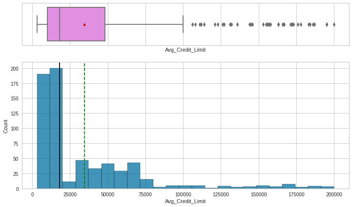

```python
histogram_boxplot(df, "Avg_Credit_Limit")
```

As expected, there are lots of outliers in the data. A majority of customers have fairly low credit limits, pushing the median downwards. Some customers have quite high credit limits, which pushes the mean upwards.

**Note** The rest of the data is not continuous and is more categorical in nature. Hence I will do a bar plot for them.

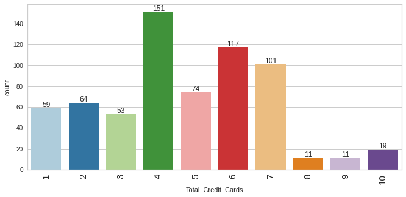

```python
labeled_barplot(df, "Total_Credit_Cards")
```

We see a distribution, which is some like a normal distribution, except that there are fewer people with 3 or 5 credit cards. It is interesting to see that there are more people with 6 or 7 credit cards than 5 credit cards. Similarly, people with 3 credit cards has an unexpected dip.

This almost looks like a 2-peak distribution. I will look at this more closely when I do bivariate analysis.

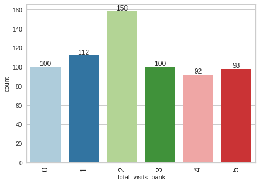

```python
labeled_barplot(df, "Total_visits_bank")
```

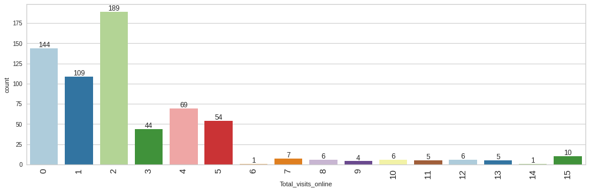

```python
labeled_barplot(df, "Total_visits_online")
```

As predicted earlier, total number of visits has a sharp right skew and plenty of outliers.

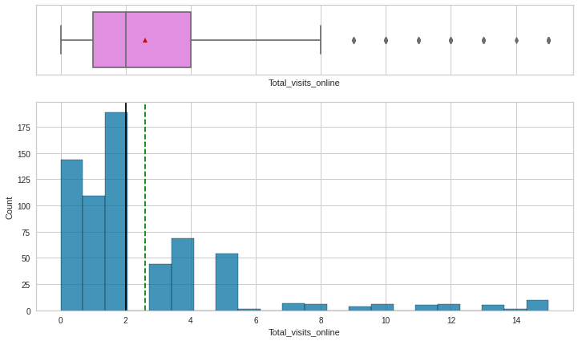

```python
# Let me confirm this with a histogram and boxplot as well
histogram_boxplot(df, "Total_visits_online")
```

The boxplot confirms the presence of outliers.

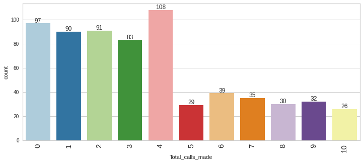

```python
labeled_barplot(df, "Total_calls_made")
```

As expected, there is a slight right skew in the data. There is a slight unexpected trend here. There seem to be more instances of people calling the bank 4 times -- makes me think that a lot of people did not get their problems resolved quickly and perhaps needed to call the bank many times.

### **Bivariate Analysis**

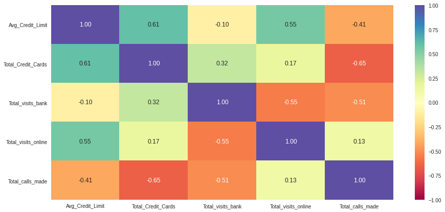

```python
# Let's start off with a heat map
plt.figure(figsize=(15, 7))
sns.heatmap(df.corr(), annot=True, vmin=-1, vmax=1, fmt=".2f", cmap="Spectral")
plt.show()
```

### **Observations**

- There are some signs of multi-collinearity between the following
- Total_Credit_Cards and Avg_Credit_Limit -- perhaps not surprising. People with higher credit scores may be issued more cards.
- Total_visits_online and Avg_Credit_Limit -- perhaps people with more credit cards log into bank more often to check their balances and credit scores.
- Negative correlation between Total_calls_made and Total_credit_cards -- perhaps the bank treats people with more credit cards as priority customers and resolves their issues quickly, whereas others might suffer.
- Fairly strong negative correlation between Total_visits_bank with Total_visits_online -- not surprising, people who do more online banking do not need to go to the bank as often.
- Fairly strong negative correlation between Total_visits_bank and Total_calls_made -- people who make more visits call the bank less often.

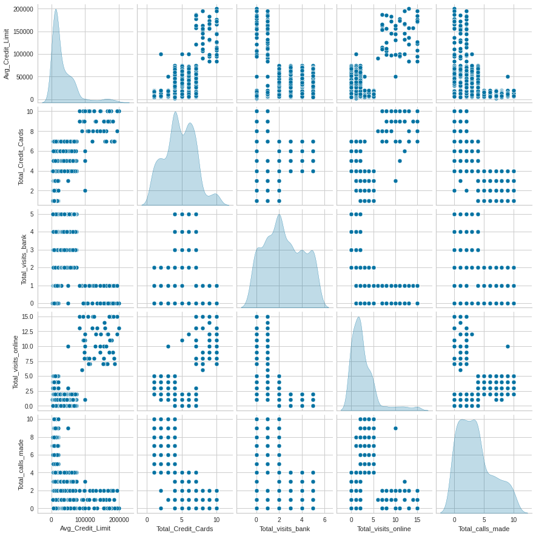

```python
# Time to do some pairplot.
sns.pairplot(data=df, diag_kind="kde")
plt.show()
```

### **Observations**

- Avg_Credit_Limit - shows signs of 3 peaks, one high, one medium, and one low.
- Total_Credit_Cards - shows 4 peaks
- Total_visits_bank - shows 5 peaks
- Total_visits_online - primarily has one large peak, and rest is flat.
- Total_calls_made - shows signs of 2 large peaks, and one medium peak.

**These multiple peaks point to different types of groups, which needs to be teased out using clustering techniques.**

The heat map had indicated some multi-collinearity between features, which is not coming through as strikingly in the scatterplots. Some trends are faintly visible though.

## **Insights Based on EDA**

The EDA reveals the following items, which will help me later with clustering and also in making recommendations to the bank.

- There are multiple peaks for each feature which points to different types of groups, which needs to be teased out using clustering techniques.
- There are some people who tend to go to the bank more often, and then there are others who tend to bank online. Those who bank online tend to not visit the bank itself much.
- People who have higher credit scores have more number of credit cards and they tend to get their issues resolved with fewer calls to the bank.
- People who have more credit cards do more online banking. From the previous point, this might also indicate that the online banking is more efficient and they need to call the bank less often.

## **K-Means Clustering**

Before we can do any clustering, we must scale the data. As we have seen, the data for credit limits has a wide range of 197,000 compared to the data for number of credit cards or number of visits to bank, which range in 10 to 15. This will make the clustering heavily influenced by the credit limits.

```python
# We need to make a copy of the data before scaling so that we preserve the non-scaled data for use later.
mycopy = df.copy()
```

```python
# I will use the standard scaler to do a z-score scaling
scaler = StandardScaler()
scaled_data = scaler.fit_transform(mycopy)
```

```python
# The scaler doesn't give me a dataframe, so I have to make it into a dataframe, and I need the original column names for the DataFrame
scaled_df = pd.DataFrame(scaled_data, columns=mycopy.columns)
```

### **Use elbow method to try to figure the value of K for the K-Means clustering**

The way I will do it is using a technqiue we learned in the MLS session, where we loop through different values of K and plot the graph to get the elbow plot.

The code here is adapted from what we did in MLS session.

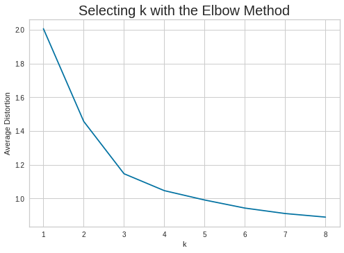

```python
clusters = range(1, 9)
meanDistortions = []

for k in clusters:
    model = KMeans(n_clusters=k)
    model.fit(scaled_df)
    prediction = model.predict(scaled_df)
    distortion = (
        sum(
            np.min(cdist(scaled_df, model.cluster_centers_, "euclidean"), axis=1)
        ) / scaled_df.shape[0]
    )
    meanDistortions.append(distortion)

plt.plot(clusters, meanDistortions, "bx-")
plt.xlabel("k")
plt.ylabel("Average Distortion")
plt.title("Selecting k with the Elbow Method", fontsize=20)
```

### **Observation**

The sharp turn in the curve (the elbow) appears to be for K = 3. The elbow method suggests that the optimal value of K is **K=3** for the K-Means clustering.

But let me check with the sihouette score as well.

### **Silhouette score**

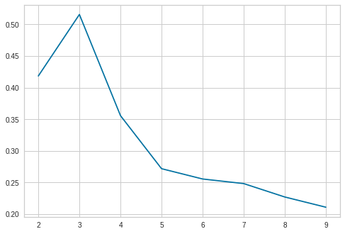

```python
# This code is adapted from the one we used in MLS class
sil_score = []
cluster_list = list(range(2, 10))
for n_clusters in cluster_list:
    clusterer = KMeans(n_clusters=n_clusters)
    preds = clusterer.fit_predict((scaled_df))
    # centers = clusterer.cluster_centers_
    score = silhouette_score(scaled_df, preds)
    sil_score.append(score)

plt.plot(cluster_list, sil_score)
```

### **Observation**

I see that the silhouette score is highest for k=3, so comparing the silhouette score for many clusters also gives us the same resule of optimal K is **K=3**.

I also see that the silhouette score is only a little bit above 0.5 and nowhere close to 1. This indicates that while this may be the best clustering possible, it is not strongly separated from other clusters.

I expect that my boxplot analysis of the various clusters will show an overlap.

### **Decision for K**

The results from the elbow technique and the silhouette scores are in agreement, so I will use a value of 3 for the K-Means clustering.

```python
# Create the 3 clusters using KMeans clustering.
```

```python
kmeans = KMeans(n_clusters=3, random_state=0)
kmeans.fit(scaled_df)
```

```
KMeans(algorithm='auto', copy_x=True, init='k-means++', max_iter=300,
       n_clusters=3, n_init=10, n_jobs=None, precompute_distances='auto',
       random_state=0, tol=0.0001, verbose=0)
```

```python
# The kmeans.labels_ identifies the various labels (clusters) that data has been assigned to.
# But I need to associate this data with the original (unscaled) data so that I can actually see the original values and the clusters they were assigned to.
# Let me assign a label that tells me that this is the label obtained from K-Means clustering so that I can later compare results from the hierarchical
# clustering as well
df["K_means_segments"] = kmeans.labels_
```

## **Hierarchical Clustering**

We had previously scaled the data, so we do not need to spend any time rescaling the data. We will use the `scaled_data` variable to do the hierarchical clustering.

```python
# Instead of trying to do the hierarchical clustering using a variety of ways to
# measure distance, I am going to stick the the EUCLIDEAN distance.
# However, I will try a variety of linkage methods to find the highest cophenetic
# distance for the various clusters.

# list of linkage methods
linkage_methods = ["single", "complete", "average", "centroid", "ward", "weighted"]

high_cophenet_corr = 0
high_dm_lm = [0, 0]

for lm in linkage_methods:
    Z = linkage(scaled_df, metric="euclidean", method=lm)
    c, coph_dists = cophenet(Z, pdist(scaled_df))
    print("Cophenetic correlation for {} linkage is {}.".format(lm, c))
    if high_cophenet_corr < c:
        high_cophenet_corr = c
        high_dm_lm[0] = "euclidean"
        high_dm_lm[1] = lm
```

```
Cophenetic correlation for single linkage is 0.7391220243806552.
Cophenetic correlation for complete linkage is 0.8599730607972423.
Cophenetic correlation for average linkage is 0.8977080867389372.
Cophenetic correlation for centroid linkage is 0.8939385846326323.
Cophenetic correlation for ward linkage is 0.7415156284827492.
Cophenetic correlation for weighted linkage is 0.8861746814895477.
```

```python
# I have my highest cophenetic correlation
print(
    "Highest cophenetic correlation is {}, which is obtained with {} linkage.".format(
        high_cophenet_corr, high_dm_lm[1]
    )
)
```

```
Highest cophenetic correlation is 0.8977080867389372, which is obtained with average linkage.
```

**Using Euclidean distance measure, I got the highest cophenetic correlation score using Average Linkage.**

Now I want to display the dendograms for the various linkages used to figure out the appropriate number of clusters. It is possible that the diagrams show me a better distribution using a different linkage method even though the cophenetic score is lower.

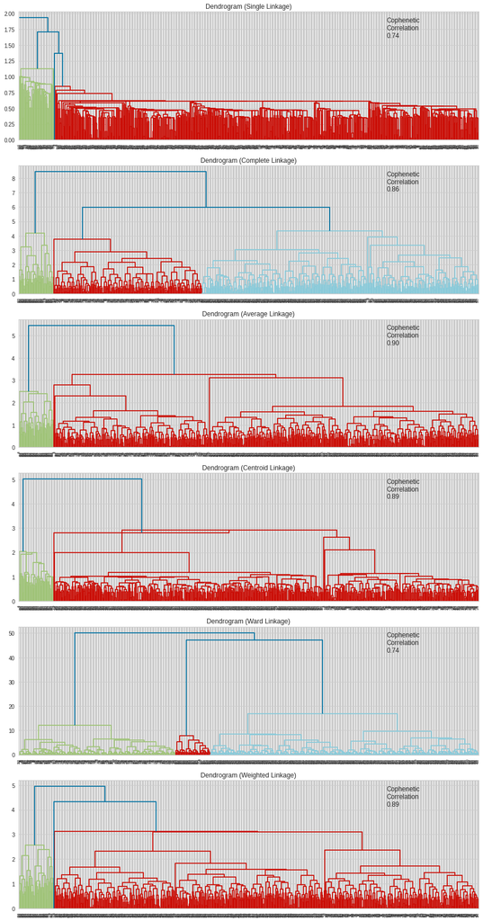

```python
# I already have the list of linkage methods in the code exxecuted above, so I
# don't need to define it again.

# lists to save results of cophenetic correlation calculation
compare_cols = ["Linkage", "Cophenetic Coefficient"]

# to create a subplot image
fig, axs = plt.subplots(len(linkage_methods), 1, figsize=(15, 30))

# We will enumerate through the list of linkage methods above
# For each linkage method, we will plot the dendrogram and calculate the cophenetic correlation
for i, method in enumerate(linkage_methods):
    Z = linkage(scaled_df, metric="euclidean", method=method)

    dendrogram(Z, ax=axs[i])
    axs[i].set_title(f"Dendrogram ({method.capitalize()} Linkage)")

    coph_corr, coph_dist = cophenet(Z, pdist(scaled_df))
    axs[i].annotate(
        f"Cophenetic\nCorrelation\n{coph_corr:0.2f}",
        (0.80, 0.80),
        xycoords="axes fraction",
    )
```

### **Observations**

- The dendogram with single linkage looks extremely messy with no clear hierarchical separation. It also has a low cophenetic correlation score of 0.74, so I will reject this.
- The dendogram for the Complete Linkage appears to be a lot cleaner in terms of separation of cluster, and it has a cophenetic correlation score of 0.86.
- The dendogram for the Average Linkage is not very clean and there isn't good separation of clusters, even though the cophenetic correlation score is 0.90. I will reject this.
- The dendogram for the Centroid Linkage is not very clean and there isn't good separation of clusters, even though the cophenetic correlation score is 0.89. I will reject this.
- The dendgram for the Ward Linkage has done a good job of separating out the clusters, even though the cophenetic correlation score is only 0.74. In fact, the distances between the clusters appears to be the highest for the Ward linkage.
- The dendogram for the Weighted Linkage has doen a poor job of separating the clusters, even though it has a cophenetic correlation score of 0.89.

### **Clustering Decision**

- I am going to proceed with the Ward linkage method for the hierarchical clustering.
- The appropriate value of K appears to be 3 from looking at the dendogram.

```python
# Let's do a clustering using ward linkage, euclidean distance, and 3 clusters.
HCmodel = AgglomerativeClustering(n_clusters=3, affinity="euclidean", linkage="ward")
HCmodel.fit(scaled_df)
```

```
AgglomerativeClustering(affinity='euclidean', compute_full_tree='auto',
                        connectivity=None, distance_threshold=None,
                        linkage='ward', memory=None, n_clusters=3)
```

```python
# Assign the labels back to the original data. Use a separate label to not override the classification we had got from K-Means clustering.
df["HC_segments"] = HCmodel.labels_
```

## **Cluster Profiling**

### **Cluster Profiling for Cluster Obtained from K-Means Clustering**

```python
# I will now prepare a cluster profile, which will let me see how many records got assgined to each of the clusters
cluster_profile_kmeans = df.groupby("K_means_segments").mean()
```

```python
# I am grouping the records in the original dataframe by the cluster labels, and then I am using the average credit limit feature to help me count the unique entries
cluster_profile_kmeans["count_in_each_segment"] = (
    df.groupby("K_means_segments")["Avg_Credit_Limit"].count().values
)
```

```python
# Display the cluster profiles
cluster_profile_kmeans.style.highlight_max(color="lightgreen", axis=0)
```

| K_means_segments | Avg_Credit_Limit | Total_Credit_Cards | Total_visits_bank | Total_visits_online | Total_calls_made | HC_segments | count_in_each_segment |
| --- | --- | --- | --- | --- | --- | --- | --- |
| 0 | 33782.383420 | 5.515544 | 3.489637 | 0.981865 | 2.000000 | 0.002591 | 386 |
| 1 | 12174.107143 | 2.410714 | 0.933036 | 3.553571 | 6.870536 | 1.000000 | 224 |
| 2 | 141040.000000 | 8.740000 | 0.600000 | 10.900000 | 1.080000 | 2.000000 | 50 |

The clusters are of different sizes with the largest cluster containing 386 records and the smallest cluster containing 50 records.

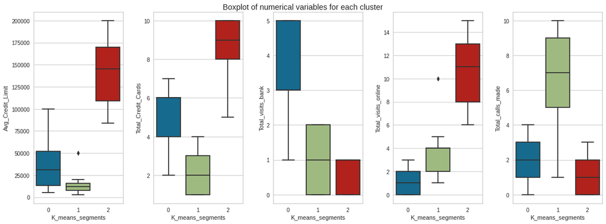

```python
# I will now use bloxplots to see how good my separation is between the clusters
# The plotting code is once again adapted from the one we discussed in MLS class.

fig, axes = plt.subplots(1, 5, figsize=(16, 6))
fig.suptitle("Boxplot of numerical variables for each cluster")
counter = 0
for ii in range(5):
    sns.boxplot(ax=axes[ii], y=df[df.columns[counter]], x=df["K_means_segments"])
    counter = counter + 1

fig.tight_layout(pad=2.0)
```

### **Cluster Profiling for Cluster Obtained from Hierarchical Clustering**

```python
# I will now prepare a cluster profile, which will let me see how many records got assgined to each of the clusters
cluster_profile_hc = df.groupby("HC_segments").mean()
```

```python
# I am grouping the records in the original dataframe by the cluster labels, and then I am using the average credit limit feature to help me count the unique entries
cluster_profile_hc["count_in_each_segment"] = (
    df.groupby("HC_segments")["Avg_Credit_Limit"].count().values
)
```

```python
# Display the cluster profiles
cluster_profile_hc.style.highlight_max(color="lightgreen", axis=0)
```

| HC_segments | Avg_Credit_Limit | Total_Credit_Cards | Total_visits_bank | Total_visits_online | Total_calls_made | K_means_segments | count_in_each_segment |
| --- | --- | --- | --- | --- | --- | --- | --- |
| 0 | 33851.948052 | 5.516883 | 3.493506 | 0.979221 | 1.994805 | 0.000000 | 385 |
| 1 | 12151.111111 | 2.422222 | 0.937778 | 3.546667 | 6.857778 | 0.995556 | 225 |
| 2 | 141040.000000 | 8.740000 | 0.600000 | 10.900000 | 1.080000 | 2.000000 | 50 |

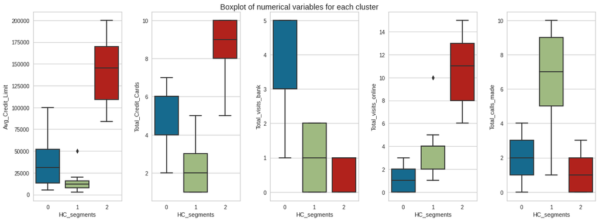

```python
# I will now use bloxplots to see how good my separation is between the clusters
# The plotting code is once again adapted from the one we discussed in MLS class.

fig, axes = plt.subplots(1, 5, figsize=(16, 6))
fig.suptitle("Boxplot of numerical variables for each cluster")
counter = 0
for ii in range(5):
    sns.boxplot(ax=axes[ii], y=df[df.columns[counter]], x=df["HC_segments"])
    counter = counter + 1

fig.tight_layout(pad=2.0)
```

### **Comparison of Clustering Results**

The K-Means clustering method as well as the hierarchical clustering method (using Ward linkage) both gave us almost identical results and clustering.

The only difference is

- K-Means placed 386 people in cluster 0 and 224 people in cluster 1.
- HC placed 385 people in cluster 0 and 225 people in cluster 1.

However, the biggest difference was in execution runtime. Whereas the K-Means clustering completed execution in seconds, the whole process of dendogram drawing took close to 5 minutes in the case of hierarchical clustering.

Another difference was the method I had to use to determine the K for the clustering. For K-Means, I had to use elbow method combined with silhouette scores to determine the appropriate value of K. On the other hand, for hierarchical, I had to carefully observe the dendogram, make a judgement call as to which dendogram did a better job of separation of clusters, and then pick the appropriate one. In fact, the one I picked (Ward linkage) didn't even have the highest cophenetic correlation score.

## **Insights**

We see three clusters that appear to be fairly well separated out. This is true for the clusters obtained through K-Means as well as that obtained through hieraarchical clustering.

**Cluster 0**

- This is the one with 386 of 660 customers (59%), so this is the majority.
- This is cluster of customers with average credit limit of about USD 34,000 and they tend to hand 4 to 6 credit cards.
- These customers tend to visit the bank the most (3 - 5 visits), and do online banking the least (0 - 2 logins per year).
- They tend to have an average of 2 calls per year to customer support and ranges from 1 - 3 calls, so the bank is doing quite well in solving the majority of customer pain with just a few calls.

**Cluster 1**

- They make up the second largest population with 224 out of 660 customers (34%)
- These customers tend to have the lowest credit limits, averaging around USD 12,000 and they tend to have 1 - 3 credit cards.
- They visit the bank very infrequently, averaging about 1 visit a year.
- They tend to use the online banking option a bit more and average 3.5 logins per year,
- They tend to make the most number of calls to customer support, averaging about 7 calls. So 34% of the customers tend to take up a significant amount of banking phone calls.

**Cluster 2**

- This is the smallest cluster with 50 out of 660 customers (7.5%).
- They have high credit limits with average of USD 141,000 and they have the most number of credit cards, averaging about 9.
- They visit the bank least frequently and do online banking most frequently.
- They also have the fewest number of calls to the customer service, so their issues are solved very rapidly, perhaps through preferential treatment.